# Ancestral State Estimation

Dean Adams (dcadams@iastate.edu)

2018-04-02

### **Overview**

Today we explore methods for estimating ancestral character states. For many macroevolutionary hypotheses, ancestral state estimation is essential. Such estimates allow us to infer the order of evolutionary transitions across the tree of life, estimate how frequently some evolutionary events have occured, and understand the initial conditions that gave rise to current patterns of phenotypic diversity.

Note, parts of this tutorial are based on and adapted from that of L. Revell: http://www.phytools.org/eqg2015/asr.html

### Download data files

To run the analyses in this tutorial, please download the following files from our Git-course repository:

[Phylogeny1](https://eeob-macroevolution.github.io/EEOB-565X-Spring2018/practicals/TutorialData/anole.gp.tre)

[Phylogeny2](https://eeob-macroevolution.github.io/EEOB-565X-Spring2018/practicals/TutorialData/anole.svl.tre)

[Data1](https://eeob-macroevolution.github.io/EEOB-565X-Spring2018/practicals/TutorialData/anole.gp.csv)

[Data2](https://eeob-macroevolution.github.io/EEOB-565X-Spring2018/practicals/TutorialData/anole.svl.csv)

Additionally, The R-script for running the code found in this tutorial is found here:

[RScript](https://eeob-macroevolution.github.io/EEOB-565X-Spring2018/practicals/TutorialData/AncStateEstimation.r)

As before, on your local computer, place them in a folder named ‘TutorialData’, which is found in the same directory as this tutorial.

### **Ancestral State Estimation of Discrete Characters**

Here we explore methods for estimating ancestral states of discrete characters. First, we bring our data into R:

```r
library(phytools)
```

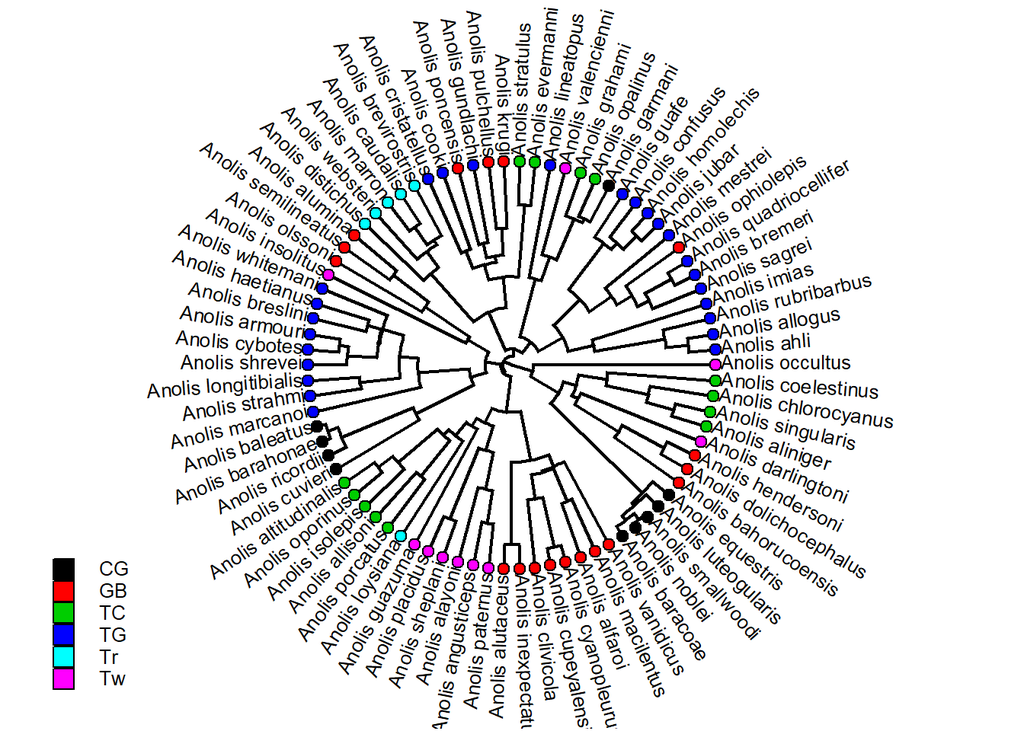

```r
library(geiger)

## 1: Read data, tree, and prune/match one to the other
## Read data & tree
tree<-read.tree("TutorialData/anole.gp.tre",tree.names=T)
group<-read.csv('TutorialData/anole.gp.csv', row.names=1, header=TRUE,colClasses=c('factor'))
gp<-as.factor(t(group)); names(gp)<-row.names(group)

#Plot
plotTree(tree,type="fan",fsize=0.8)
cols<-setNames(palette()[1:length(unique(gp))],sort(unique(gp)))
tiplabels(pie=model.matrix(~gp-1),piecol=cols,cex=0.3)
add.simmap.legend(colors=cols,prompt=FALSE,x=0.9*par()$usr[1],
                  y=-max(nodeHeights(tree)),fsize=0.8)
```

Here we see our phylogeny and our discrete character states for the extant taxa. This is a phylogeny of *Anolis* lizards and their habitat use. Species tend to concentrate their activities to particular habitat types. Thus, some interesting questions might be:

1. What is the ancestral *Anolis* habitat type?
2. Are species utilizing the same habitat each others’ closest relatives (i.e., are they monophyletic clades)?
3. How many times have species evolved to utilize a specific habitat?

#### **Discrete Characters: Maximum Parsimony**

One method for estimating ancestral character states is based on maximum parsimony (MP). Here the goal is to minimize the total number of changes between character states across the phylogeny to reconcile the data at the tips of the phylogeny with the topology of the phylogeny.

However, while MP methods are straight-forward to understand and quick to implement, they have several serious deficiencies. First, all transitions between traits are considered to be equally likely; which is related to the fact that transitions between states are equally weighted. These assumptions are clearly violated with real data. Also, and critically, branch length information is completely ignored using maximum parsimony. **For these reasons, we will NOT demonstrate MP approaches in this tutorial!**

#### **Discrete Characters: Maximum Likelihood**

An alternative is to use a model-based approach such as maximum likelihood (ML). Here we model the evolutionary transitions between character states, and select those ancestral values that maximize the likelihood of the data, conditioned on the phylogeny, the model, and the ancestral states. Here we perform this analysis in R:

```r
anc.ML<-ace(gp,tree,model="ER",type="discrete")
  round(anc.ML$lik.anc[1:10,],3)  #show result:
```

```
##          CG    GB    TC    TG    Tr    Tw
##  [1,] 0.018 0.202 0.043 0.429 0.004 0.304
##  [2,] 0.008 0.197 0.020 0.501 0.001 0.272
##  [3,] 0.003 0.134 0.020 0.716 0.005 0.122
##  [4,] 0.002 0.042 0.019 0.858 0.002 0.077
##  [5,] 0.000 0.001 0.001 0.995 0.000 0.002
##  [6,] 0.000 0.000 0.000 0.998 0.000 0.001
##  [7,] 0.000 0.000 0.000 1.000 0.000 0.000
##  [8,] 0.000 0.000 0.000 1.000 0.000 0.000
##  [9,] 0.000 0.000 0.000 1.000 0.000 0.000
## [10,] 0.000 0.000 0.000 1.000 0.000 0.000
```

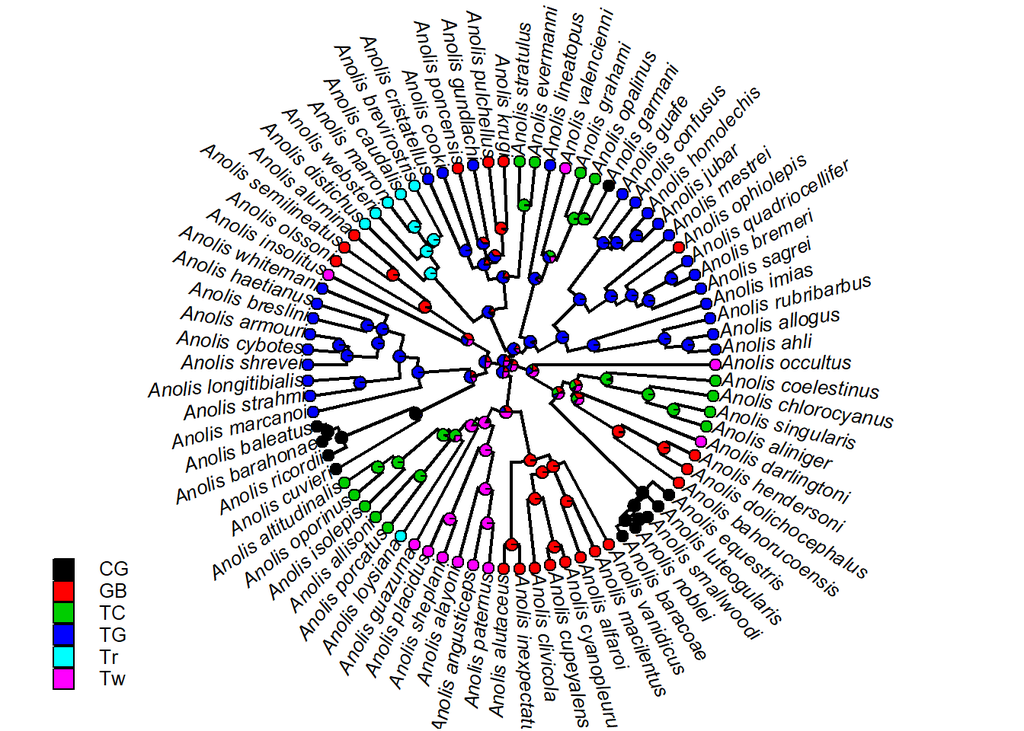

```r
#PLOT
plotTree(tree,type="fan",fsize=0.8,ftype="i")
cols<-setNames(palette()[1:length(unique(gp))],sort(unique(gp)))
nodelabels(node=1:tree$Nnode+Ntip(tree),
           pie=anc.ML$lik.anc,piecol=cols,cex=0.3)
tiplabels(pie=model.matrix(~gp-1),piecol=cols,cex=0.3)
add.simmap.legend(colors=cols,prompt=FALSE,x=0.9*par()$usr[1],
                  y=-max(nodeHeights(tree)),fsize=0.8)
```

Again, note that internal nodes are estimated as combinations of different states. This reflects the fact that no single state is 100% likely for those nodes.

#### **Discrete Characters: Bayesian Stochastic Mapping**

An alternative to ML approaches is to utilize a Bayesian perspective. Here, a Markov process is used to model trait evolution on the phylogeny, given a model of transition rates between states. A single iteration yields what is called a *stochastic map*; representing one possible embodiment of evolution under the Markov process. Repeating this many times and summarizing the values provides a useful estimate of ancestral states. Here we perform this analysis in R:

```r
tree.smp1<-make.simmap(tree,gp,model="ER")
```

```
## make.simmap is sampling character histories conditioned on the transition matrix
##
## Q =
##             CG          GB          TC          TG          Tr          Tw
## CG -0.11570723  0.02314145  0.02314145  0.02314145  0.02314145  0.02314145
## GB  0.02314145 -0.11570723  0.02314145  0.02314145  0.02314145  0.02314145
## TC  0.02314145  0.02314145 -0.11570723  0.02314145  0.02314145  0.02314145
## TG  0.02314145  0.02314145  0.02314145 -0.11570723  0.02314145  0.02314145
## Tr  0.02314145  0.02314145  0.02314145  0.02314145 -0.11570723  0.02314145
## Tw  0.02314145  0.02314145  0.02314145  0.02314145  0.02314145 -0.11570723
## (estimated using likelihood);
## and (mean) root node prior probabilities
## pi =
##        CG        GB        TC        TG        Tr        Tw
## 0.1666667 0.1666667 0.1666667 0.1666667 0.1666667 0.1666667
```

```
## Done.
```

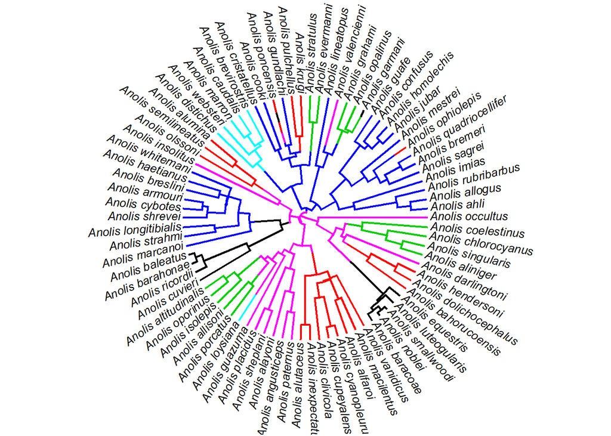

```r
plot(tree.smp1,cols,type="fan",fsize=0.8,ftype="i")  #one run.  Not overly useful.
```

```r
#Must do many times
tree.smp<-make.simmap(tree,gp,model="ER",nsim=100)
```

```
## make.simmap is sampling character histories conditioned on the transition matrix
##
## Q =
##             CG          GB          TC          TG          Tr          Tw
## CG -0.11570723  0.02314145  0.02314145  0.02314145  0.02314145  0.02314145
## GB  0.02314145 -0.11570723  0.02314145  0.02314145  0.02314145  0.02314145
## TC  0.02314145  0.02314145 -0.11570723  0.02314145  0.02314145  0.02314145
## TG  0.02314145  0.02314145  0.02314145 -0.11570723  0.02314145  0.02314145
## Tr  0.02314145  0.02314145  0.02314145  0.02314145 -0.11570723  0.02314145
## Tw  0.02314145  0.02314145  0.02314145  0.02314145  0.02314145 -0.11570723
## (estimated using likelihood);
## and (mean) root node prior probabilities
## pi =
##        CG        GB        TC        TG        Tr        Tw
## 0.1666667 0.1666667 0.1666667 0.1666667 0.1666667 0.1666667
```

```
## Done.
```

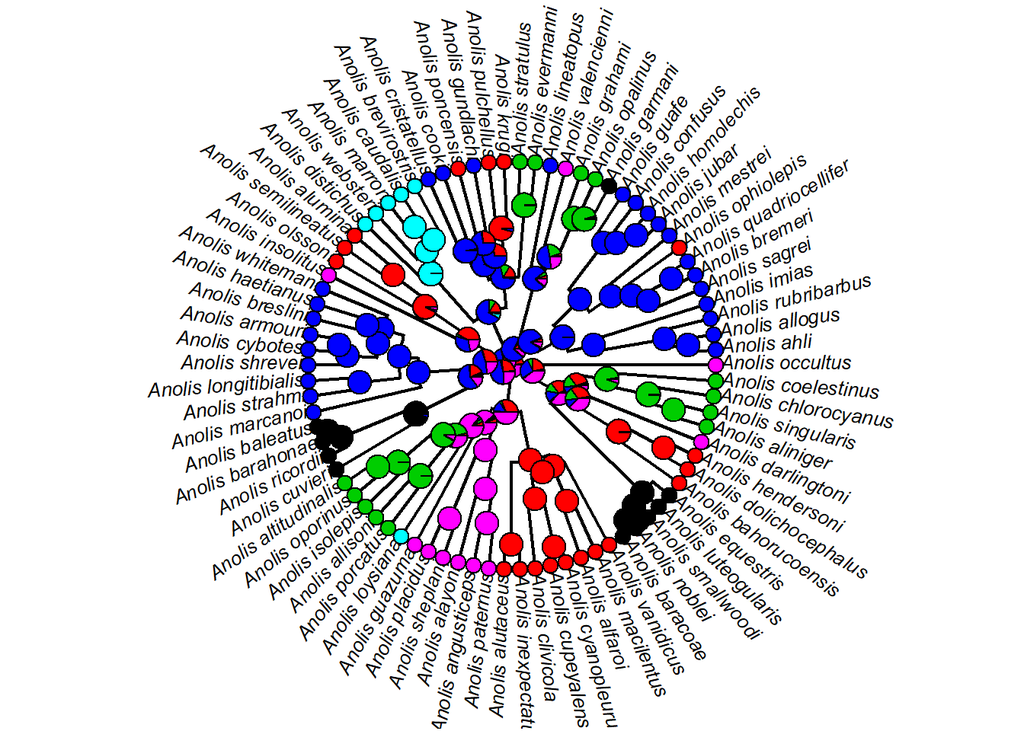

```r
anc.smp<-summary(tree.smp,plot=FALSE)
plot(anc.smp, type="fan", fsize=0.8,ftype="i")
```

```r
rm(list = ls())
```

Again, note that internal nodes are estimated as combinations of different states. This reflects the fact that no single state is 100% likely for those nodes.

#### **Continuous Characters: Maximum Likelihood**

For continuous characters, one envisions evolution under a Brownian motion model, which is the embodiment of a Markov process on a continuous scale. Fortunately, the ML algorithm above can accomodate such patterns of character evolution:

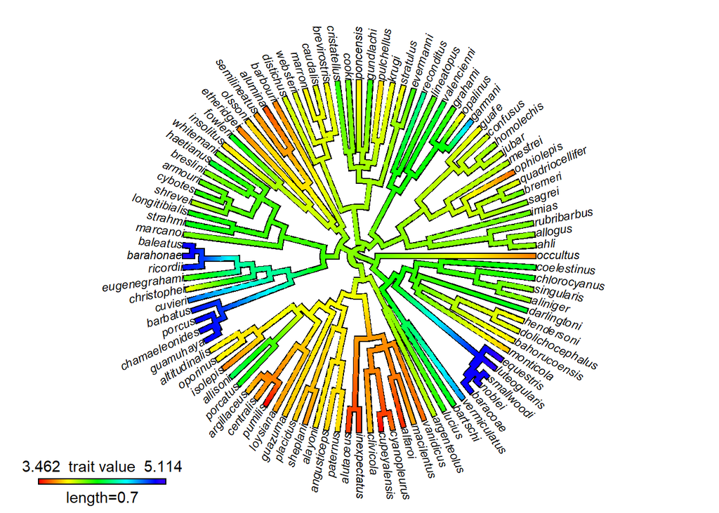

```r
#Data from Mahler et al. 2010. Evolution
tree<-read.tree("TutorialData/anole.svl.tre",tree.names=T)
svl<-read.csv('TutorialData/anole.svl.csv', row.names=1, header=TRUE)
svl<-as.matrix(svl)[,1]  #change to vector
anc.cont.ML<-fastAnc(tree,svl,vars=TRUE,CI=TRUE)
  #anc.cont.ML #output: estimate and 95% CI

#PLOT as color map
tree.col<-contMap(tree,svl,plot=FALSE)  #runs Anc. St. Est. on branches of tree
plot(tree.col,type="fan",legend=0.7*max(nodeHeights(tree)),
     fsize=c(0.7,0.9))
```

```r
#Data from Mahler et al. 2010. Evolution
#using 'ace' function in APE
anc.cont.ML2<-ace(x=svl,phy=tree, type="continuous", method="ML")
anc.cont.ML2$ace  #with APE
```

```
##      101      102      103      104      105      106      107      108
## 4.065918 4.045601 4.047994 4.066924 4.036744 4.049515 4.054528 4.045217
##      109      110      111      112      113      114      115      116
## 3.979493 3.952440 3.926814 3.964414 3.995836 3.948034 3.955203 3.977842
##      117      118      119      120      121      122      123      124
## 4.213996 4.240867 4.248450 4.257574 4.239062 4.004120 4.007024 4.015249
##      125      126      127      128      129      130      131      132
## 4.006720 3.992617 3.925847 3.995759 4.049618 3.930793 3.908343 3.901518
##      133      134      135      136      137      138      139      140
## 3.885086 4.040356 4.060970 3.987789 3.951879 3.814014 3.707733 3.926147
##      141      142      143      144      145      146      147      148
## 3.988745 4.167984 4.157022 4.166146 4.146361 4.146131 4.159052 4.113266
##      149      150      151      152      153      154      155      156
## 4.133068 4.222223 4.461376 4.488495 4.437250 4.512070 4.953146 5.033253
##      157      158      159      160      161      162      163      164
## 4.962377 5.009025 5.018390 3.974901 3.880483 3.859269 3.859265 3.871896
##      165      166      167      168      169      170      171      172
## 3.899914 3.807943 3.826619 4.151598 3.760445 3.654324 3.676713 3.825559
##      173      174      175      176      177      178      179      180
## 3.747726 3.813974 3.803077 3.702349 3.566476 3.678236 3.675619 3.662451
##      181      182      183      184      185      186      187      188
## 3.563181 3.645426 4.017460 4.113690 4.229394 4.381610 4.243154 5.041281
##      189      190      191      192      193      194      195      196
## 5.051563 5.051719 5.057591 4.183654 4.151505 4.113280 3.969795 3.905123
##      197      198      199
## 4.191810 4.161419 4.092141
```

```r
anc.cont.ML$ace   #with phytools: the same estimates
```

```
##      101      102      103      104      105      106      107      108
## 4.065918 4.045601 4.047993 4.066923 4.036743 4.049514 4.054528 4.045218
##      109      110      111      112      113      114      115      116
## 3.979493 3.952440 3.926814 3.964414 3.995835 3.948034 3.955203 3.977842
##      117      118      119      120      121      122      123      124
## 4.213995 4.240867 4.248450 4.257574 4.239061 4.004120 4.007024 4.015249
##      125      126      127      128      129      130      131      132
## 4.006720 3.992617 3.925848 3.995759 4.049619 3.930793 3.908343 3.901518
##      133      134      135      136      137      138      139      140
## 3.885086 4.040356 4.060970 3.987789 3.951878 3.814014 3.707733 3.926147
##      141      142      143      144      145      146      147      148
## 3.988745 4.167983 4.157021 4.166146 4.146362 4.146132 4.159052 4.113267
##      149      150      151      152      153      154      155      156
## 4.133069 4.222223 4.461376 4.488496 4.437250 4.512071 4.953146 5.033253
##      157      158      159      160      161      162      163      164
## 4.962377 5.009025 5.018389 3.974900 3.880482 3.859268 3.859265 3.871895
##      165      166      167      168      169      170      171      172
## 3.899914 3.807943 3.826619 4.151598 3.760446 3.654324 3.676713 3.825559
##      173      174      175      176      177      178      179      180
## 3.747726 3.813974 3.803077 3.702349 3.566476 3.678236 3.675620 3.662452
##      181      182      183      184      185      186      187      188
## 3.563181 3.645426 4.017460 4.113689 4.229393 4.381609 4.243153 5.041281
##      189      190      191      192      193      194      195      196
## 5.051563 5.051719 5.057591 4.183653 4.151505 4.113279 3.969795 3.905122
##      197      198      199
## 4.191810 4.161419 4.092141
```

```r
anc.cont.gls<-ace(x=svl,phy=tree, corStruct = corBrownian(1, tree), method="GLS")  #same as ML  (see Schluter et al. 1997)
anc.cont.gls$ace   #GLS: SCP. the same
```

```
##      101      102      103      104      105      106      107      108
## 4.065918 4.045601 4.047993 4.066923 4.036743 4.049514 4.054528 4.045218
##      109      110      111      112      113      114      115      116
## 3.979493 3.952440 3.926814 3.964414 3.995835 3.948034 3.955203 3.977842
##      117      118      119      120      121      122      123      124
## 4.213995 4.240867 4.248450 4.257574 4.239061 4.004120 4.007024 4.015249
##      125      126      127      128      129      130      131      132
## 4.006720 3.992617 3.925848 3.995759 4.049619 3.930793 3.908343 3.901518
##      133      134      135      136      137      138      139      140
## 3.885086 4.040356 4.060970 3.987789 3.951878 3.814014 3.707733 3.926147
##      141      142      143      144      145      146      147      148
## 3.988745 4.167983 4.157021 4.166146 4.146362 4.146132 4.159052 4.113267
##      149      150      151      152      153      154      155      156
## 4.133069 4.222223 4.461376 4.488496 4.437250 4.512071 4.953146 5.033253
##      157      158      159      160      161      162      163      164
## 4.962377 5.009025 5.018389 3.974900 3.880482 3.859268 3.859265 3.871895
##      165      166      167      168      169      170      171      172
## 3.899914 3.807943 3.826619 4.151598 3.760446 3.654324 3.676713 3.825559
##      173      174      175      176      177      178      179      180
## 3.747726 3.813974 3.803077 3.702349 3.566476 3.678236 3.675620 3.662452
##      181      182      183      184      185      186      187      188
## 3.563181 3.645426 4.017460 4.113689 4.229393 4.381609 4.243153 5.041281
##      189      190      191      192      193      194      195      196
## 5.051563 5.051719 5.057591 4.183653 4.151505 4.113279 3.969795 3.905122
##      197      198      199
## 4.191810 4.161419 4.092141
```

#### **Continuous Characters: Bayesian Estimation with Fossils**

Many times, it is prudent to incorporate fossil information when available. This is **critically important**, as fossils provide calibration for the remaining estimates. Conceptually, fossils act much like an anchor, and allow one to condition the ancestral estimates on the phylogeny, the model, and the fossils. An example below (via simulation) shows the difference in estimates with and without ‘fossil’ priors:

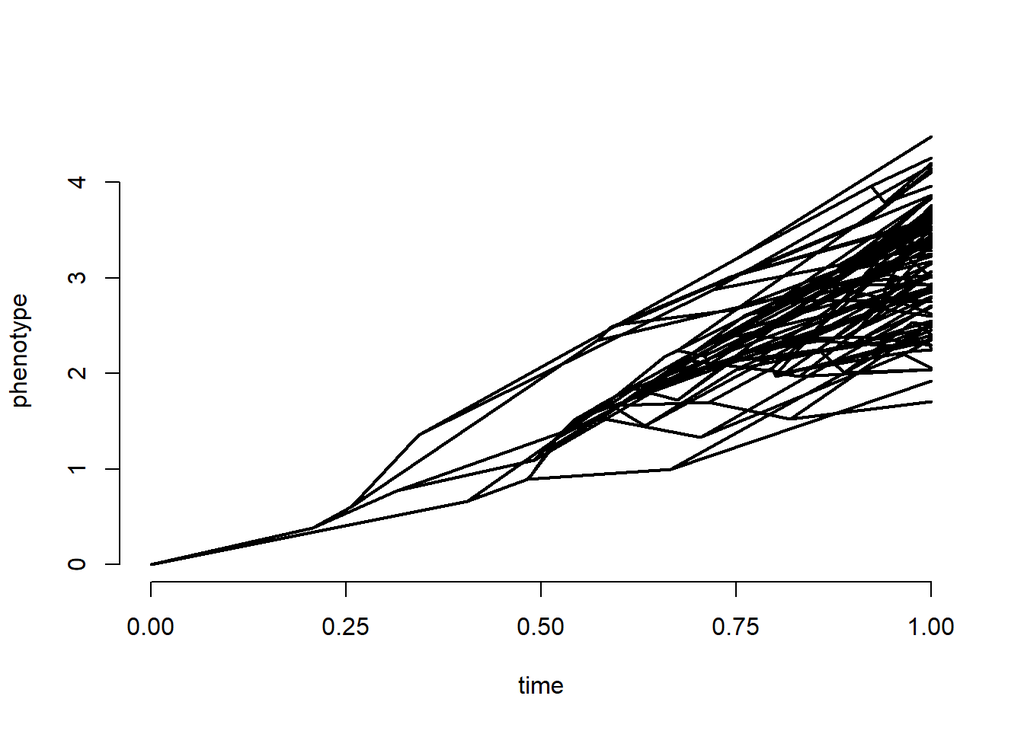

```r
tree<-pbtree(n=100,scale=1)
## simulate data with a trend
x<-fastBM(tree,internal=TRUE,mu=3)
phenogram(tree,x,ftype="off")
```

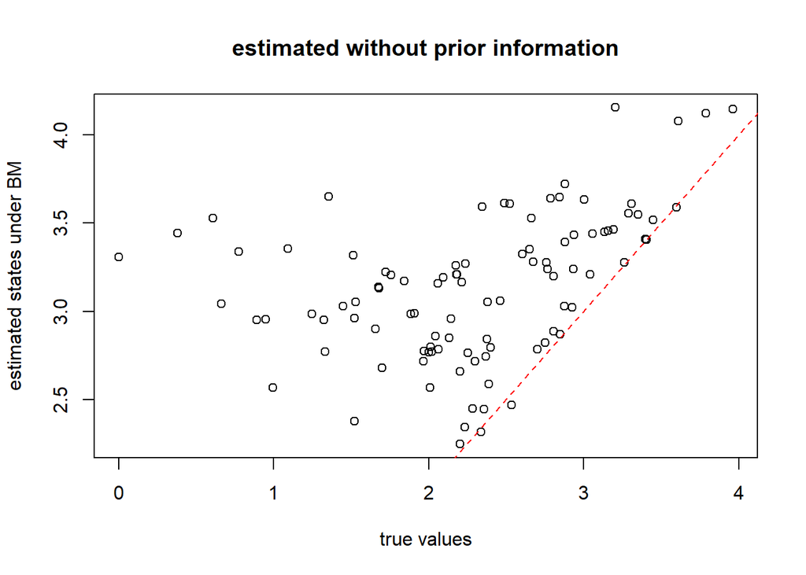

```r
#estimate with no prior
a<-x[as.character(1:tree$Nnode+Ntip(tree))]
x<-x[tree$tip.label]
## let's see how bad we do if we ignore the trend
plot(a,fastAnc(tree,x),xlab="true values",
     ylab="estimated states under BM")
lines(range(c(x,a)),range(c(x,a)),lty="dashed",col="red")
title("estimated without prior information")
```

```r
## incorporate prior knowledge
pm<-setNames(c(1000,rep(0,tree$Nnode)),
             c("sig2",1:tree$Nnode+length(tree$tip.label)))
## the root & two randomly chosen nodes
nn<-as.character(c(length(tree$tip.label)+1,
                   sample(2:tree$Nnode+length(tree$tip.label),2)))
pm[nn]<-a[as.character(nn)]
## prior variance
pv<-setNames(c(1000^2,rep(1000,length(pm)-1)),names(pm))
pv[as.character(nn)]<-1e-100
## run MCMC
mcmc<-anc.Bayes(tree,x,ngen=100000,
                control=list(pr.mean=pm,pr.var=pv,
                             a=pm[as.character(length(tree$tip.label)+1)],
                             y=pm[as.character(2:tree$Nnode+length(tree$tip.label))]))
```

```
## Control parameters (set by user or default):
```

```
## List of 7
##  $ sig2   : num 0.868
##  $ a      : Named num 0
##   ..- attr(*, "names")= chr "101"
##  $ y      : Named num [1:98] 0 0 0 0 0 0 0 0 0 0 ...
##   ..- attr(*, "names")= chr [1:98] "102" "103" "104" "105" ...
##  $ pr.mean: Named num [1:100] 1000 0 0 0 0 0 0 0 0 0 ...
##   ..- attr(*, "names")= chr [1:100] "sig2" "101" "102" "103" ...
##  $ pr.var : Named num [1:100] 1e+06 1e-100 1e+03 1e+03 1e+03 ...
##   ..- attr(*, "names")= chr [1:100] "sig2" "101" "102" "103" ...
##  $ prop   : num [1:100] 0.00868 0.00868 0.00868 0.00868 0.00868 ...
##  $ sample : num 100
```

```
## Starting MCMC...
```

```
## Done MCMC.
```

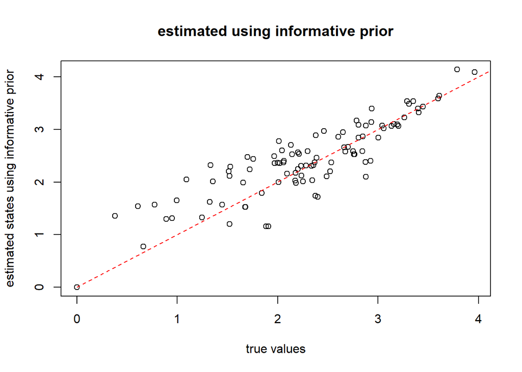

```r
anc.est<-colMeans(mcmc$mcmc[201:1001,as.character(1:tree$Nnode+length(tree$tip.label))])

plot(a,anc.est,xlab="true values",
     ylab="estimated states using informative prior")
lines(range(c(x,a)),range(c(x,a)),lty="dashed",col="red")
title("estimated using informative prior")
```